# Linear regression simple example

Adi Sarid

July 2019

## Read the dataset

We’re using a data set with countries and the various types of alchohol consumption. The dataset was downloaded from the [tidytuesday project](https://github.com/rfordatascience/tidytuesday), the data set from Tuesday the 26th, 2018.

We also add some country metadata from the [worldbank](https://data.worldbank.org/) and classification to continents from [here](https://datahub.io/JohnSnowLabs/country-and-continent-codes-list#data), then filtered some countries with missing data.

```r
alchohol <- read_csv("https://github.com/sarid-ins/statistical_learning_course/raw/master/datasets/alchohol_consumption/alchohol_consumption_ready.csv")
```

## The beer model

How much beer is drank, as a function of spirit, wine, gdp per capita, and continent? Beer, spirit, and wine data for 2010, servings consumed per person, see [fivethirtyeight](https://fivethirtyeight.com/features/dear-mona-followup-where-do-people-drink-the-most-beer-wine-and-spirits/).

```r
beer_lm <- lm(beer_servings ~ spirit_servings + wine_servings + gdp2010 + Continent_Name,
              data = alchohol)

summary(beer_lm)
```

```
##
## Call:
## lm(formula = beer_servings ~ spirit_servings + wine_servings +
##     gdp2010 + Continent_Name, data = alchohol)
##
## Residuals:
##     Min      1Q  Median      3Q     Max
## -191.13  -43.58  -11.02   32.21  321.74
##
## Coefficients:
##                               Estimate Std. Error t value Pr(>|t|)
## (Intercept)                  5.114e+01  1.126e+01   4.543 1.07e-05 ***
## spirit_servings              3.646e-01  8.128e-02   4.486 1.36e-05 ***
## wine_servings                4.272e-01  9.421e-02   4.534 1.11e-05 ***
## gdp2010                      3.000e-04  3.353e-04   0.895   0.3722
## Continent_NameAsia          -4.659e+01  1.730e+01  -2.694   0.0078 **
## Continent_NameEurope         2.542e+01  2.331e+01   1.091   0.2770
## Continent_NameNorth America  2.151e+01  2.432e+01   0.884   0.3778
## Continent_NameOceania        9.560e+00  2.372e+01   0.403   0.6874
## Continent_NameSouth America  3.611e+01  2.691e+01   1.342   0.1815
## ---
## Signif. codes:  0 '***' 0.001 '**' 0.01 '*' 0.05 '.' 0.1 ' ' 1
##
## Residual standard error: 74.87 on 164 degrees of freedom
## Multiple R-squared:  0.4938, Adjusted R-squared:  0.4691
## F-statistic: 19.99 on 8 and 164 DF,  p-value: < 2.2e-16
```

Let’s analyze this model, step-by-step.

### The `Call:`

First, the `Call:` simply repeats what we “ordered”.

### Residuals

The residuals provide the individual errors, i.e. the elements of the RSS (residual sum of squares).

**Question: what is the average of the residuals?**

No matter, we can still make do.

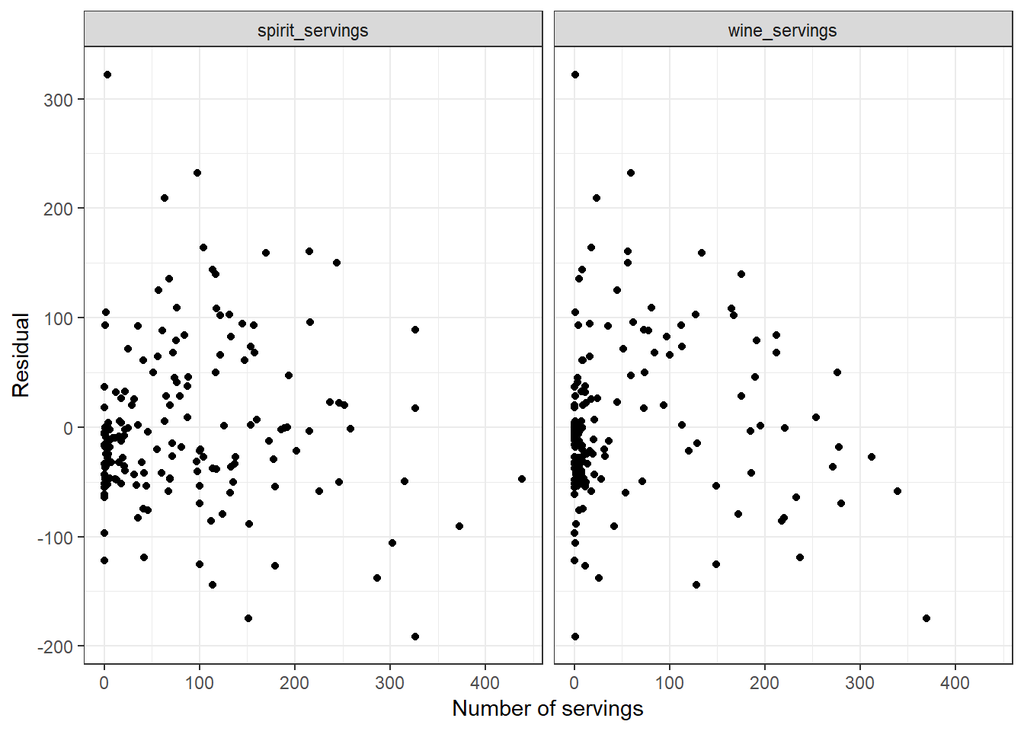

```r
alchohol_residuals <- alchohol %>%
         mutate(res = beer_lm$residuals) %>%
         select(country, spirit_servings:wine_servings, res) %>%
         gather(variable, x_value, -res, -country)

ggplot(alchohol_residuals,
       aes(x = x_value, y = res)) +
  geom_point() +
  facet_wrap(~ variable) +
  theme_bw() +
  ylab("Residual") +
  xlab("Number of servings")
```

```r
alchohol %>%
  mutate(res = beer_lm$residuals) %>%
  select(country, spirit_servings:wine_servings, res) %>%
  arrange(desc(res)) %>%
  head() %>%
  knitr::kable()
```

| country | spirit_servings | wine_servings | res |
| --- | --- | --- | --- |
| Namibia | 3 | 1 | 321.7404 |
| Gabon | 98 | 59 | 232.2737 |
| Palau | 63 | 23 | 209.4492 |
| Panama | 104 | 18 | 164.3205 |
| Poland | 215 | 56 | 160.3494 |
| Czech Republic | 170 | 134 | 159.2741 |

### The regression table

Enough about residuals, let’s talk about the coefficients table. The `(intercept)` represents the model’s $\beta_0$. The rest of the coefficients, as specified.

- `Estimate` is the $\beta$ itself.
- `Std. Error` is the estimate’s variance (e.g., if we do this “measurement survey” again, and again, we might get some variations of the data. For each such variation we will get a different $\hat{\beta_i}$’s. These coefficients have a distribution, and this is an estimate to their standard error.
- The `t value` and the `Pr(>|t|)` (a.k.a., p-value) are significance tests based on the normal distribution, with statistic $\hat{\beta}_i$ and $\sigma$ as the std. error. A really high `t value` corresponds with a really low `Pr(>|t|)` value, and indicates that the coefficient is different than $0$.
- The stars indicate various levels of p-value. Special attention is given to $p<0.05$, though the p-value is [heavily disputed](https://amstat.tandfonline.com/doi/full/10.1080/00031305.2016.1154108#.XSx3YugzaUk) in our era of really big samples.

### Treatment of categorial variables

Note the special treatment of categorial variables (i.e., `Continent`).

**How many continents in the regression versus the levels in the data? why?**

### The residual starndard error

The residual standard error, at the buttom of the table, reports an estimate for the $\epsilon$’s (error) standard deviation. While degrees of freedom signifies the sample size minus the number of coefficients, i.e.: $df=n-p-1$.

### Multiple $R^2$ and Adjusted $R^2$

These measure the fitness of the model. The $R^2$ is the proportion of our model to a nominal naive model (a simple average). The Adjusted $R^2$ uses a similar approach but “fines” the use of many features.

### The F-Statistic (and hypothesis testing)

The F-statistic is the ratio of:

$$F = \frac{(TSS-RSS)/p}{RSS/(n-p-1)}$$

It has its own “F distribution” when normality and homoschedastity of the model are assumed.

Is can be used for the significance test which examines the hypothesis:
$$H_0:\beta_0=\beta_1=\beta_2=\ldots=\beta_p=0\\$$
Versus the alternative (at least one $\beta_i$ is non-zero)

Really high values of $F$ correspond to really low p-values, validating in a sense an overall relationship between the response and predictors.

# Transformations

We can use various transformations on-the-fly, when the variables are entered into the regression model.

**What transformation would you try on the gdp per capita variable to improve the model?**

```r
head(alchohol, 15) %>%
  select(country:Continent_Name) %>%
  knitr::kable()
```

| country | beer_servings | spirit_servings | wine_servings | total_litres_of_pure_alcohol | Country Code | gdp2010 | Continent_Name |
| --- | --- | --- | --- | --- | --- | --- | --- |
| Afghanistan | 0 | 0 | 0 | 0.0 | AFG | 543.3030 | Asia |
| Albania | 89 | 132 | 54 | 4.9 | ALB | 4094.3588 | Europe |
| Algeria | 25 | 0 | 14 | 0.7 | DZA | 4480.7858 | Africa |
| Andorra | 245 | 138 | 312 | 12.4 | AND | 39736.3541 | Europe |
| Angola | 217 | 57 | 45 | 5.9 | AGO | 3587.8838 | Africa |
| Argentina | 193 | 25 | 221 | 8.3 | ARG | 10385.9644 | South America |
| Armenia | 21 | 179 | 11 | 3.8 | ARM | 3218.3727 | Europe |
| Armenia | 21 | 179 | 11 | 3.8 | ARM | 3218.3727 | Asia |
| Australia | 261 | 72 | 212 | 10.4 | AUS | 52022.1256 | Oceania |
| Austria | 279 | 75 | 191 | 9.7 | AUT | 46858.0433 | Europe |
| Azerbaijan | 21 | 46 | 5 | 1.3 | AZE | 5842.8058 | Europe |
| Azerbaijan | 21 | 46 | 5 | 1.3 | AZE | 5842.8058 | Asia |
| Bahrain | 42 | 63 | 7 | 2.0 | BHR | 20722.1373 | Asia |
| Bangladesh | 0 | 0 | 0 | 0.0 | BGD | 781.1536 | Asia |
| Barbados | 143 | 173 | 36 | 6.3 | BRB | 16056.0165 | North America |

### Relative importance with `relaimpo`

Each time we add a new variable to a model, our $R^2$ increases by a certain amount. However, the contribution of a new variable changes according to variables already in the model. For example:

```r
# just spirit
summary(lm(beer_servings ~ spirit_servings, alchohol))$r.squared
```

```
## [1] 0.2079052
```

```r
# just wine
summary(lm(beer_servings ~ wine_servings, alchohol))$r.squared
```

```
## [1] 0.3006061
```

```r
# spirit and wine
summary(lm(beer_servings ~ spirit_servings + wine_servings, alchohol))$r.squared
```

```
## [1] 0.4296968
```

```r
# adding continent
summary(lm(beer_servings ~ spirit_servings + Continent_Name, alchohol))$r.squared
```

```
## [1] 0.4141153
```

```r
summary(lm(beer_servings ~ wine_servings + Continent_Name, alchohol))$r.squared
```

```
## [1] 0.4316386
```

```r
summary(lm(beer_servings ~ spirit_servings + wine_servings + Continent_Name, alchohol))$r.squared
```

```
## [1] 0.4912864
```

The `relaimpo` package provides an analysis on all combinations (of the average $R^2$ increase). Note the use of `factor` to transform `Continent_Name` (otherwise the function fails).

```r
#install.packages(relaimpo)

relaimpo::calc.relimp(lm(beer_servings ~ spirit_servings + wine_servings + log(gdp2010) + factor(Continent_Name), alchohol))
```

```
## Response variable: beer_servings
## Total response variance: 10558.23
## Analysis based on 173 observations
##
## 8 Regressors:
## Some regressors combined in groups:
##         Group  factor(Continent_Name) : `factor(Continent_Name)`Asia `factor(Continent_Name)`Europe `factor(Continent_Name)`North America `factor(Continent_Name)`Oceania `factor(Continent_Name)`South America
##
##  Relative importance of 4 (groups of) regressors assessed:
##  factor(Continent_Name) spirit_servings wine_servings log(gdp2010)
##
## Proportion of variance explained by model: 54.33%
## Metrics are not normalized (rela=FALSE).
##
## Relative importance metrics:
##
##                              lmg
## factor(Continent_Name) 0.1764205
## spirit_servings        0.1080098
## wine_servings          0.1260581
## log(gdp2010)           0.1328353
##
## Average coefficients for different model sizes:
##
##                                            1group     2groups     3groups
## spirit_servings                         0.5249799   0.3706854   0.3535413
## wine_servings                           0.6799655   0.4812088   0.3753354
## log(gdp2010)                           37.8577784  27.7511732  23.1456723
## `factor(Continent_Name)`Asia          -23.9750000 -42.0779330 -59.2851049
## `factor(Continent_Name)`Europe        129.7555556  74.7148436  27.3429281
## `factor(Continent_Name)`North America  80.0000000  49.5335136  19.0515076
## `factor(Continent_Name)`Oceania        26.1538462  10.1114990  -3.3365420
## `factor(Continent_Name)`South America  95.7272727  63.5128054  34.2512624
##                                           4groups
## spirit_servings                         0.3573913
## wine_servings                           0.2805833
## log(gdp2010)                           23.0988208
## `factor(Continent_Name)`Asia          -73.8191670
## `factor(Continent_Name)`Europe         -8.2288760
## `factor(Continent_Name)`North America  -7.9924477
## `factor(Continent_Name)`Oceania       -13.1121545
## `factor(Continent_Name)`South America  10.7834343
```

Surprisingly, the continent is found to have the largest “lmg” (short for Lindeman, Merenda and Gold which wrote the original paper), which is the $R^2$ contribution averaged over orderings among regressors.

### Feature selection

There are a number of “greedy” feature selection algorithms, known as stepwise: forwards, backwards, forward-backward. Each algorithm starts from an initial model, define it as the “incumbent model”.

At each iteration, the algorithm runs all `lm` combinations of adding (or removing or adding/removing) a single feature to the incumbent model.

The algorithm selects the best model out of the examined models, using a criteria (e.g., AIC), and updates the “incumbent model”.

The algorithm stops when the incumbent model cannot be improved.

In R, the function `MASS:stepAIC` can be used for stepwise. It utilizes the AIC (Akaike information criterion):

$$AIC = -2\ln(\hat{L}) + 2k$$

Where $\hat{L}$ is the likelihood and is defined as:

$$\hat{L}(\theta) = f(y_1|\theta)\times\ldots\times f(y_n|\theta)=\Pi_{t=1}^nf(y_t|\theta)$$

In the case of linear regression, the AIC is equivalent to $2k+n\ln(RSS)$.

We illustrate the use of `stepAIC`.

```r
beer_step_bth <- MASS::stepAIC(beer_lm, direction = "both")
```

```
## Start:  AIC=1502.02
## beer_servings ~ spirit_servings + wine_servings + gdp2010 + Continent_Name
##
##                   Df Sum of Sq     RSS    AIC
## - gdp2010          1      4489  923832 1500.9
## <none>                          919343 1502.0
## - Continent_Name   5    111677 1031020 1511.8
## - spirit_servings  1    112799 1032142 1520.0
## - wine_servings    1    115243 1034586 1520.5
##
## Step:  AIC=1500.86
## beer_servings ~ spirit_servings + wine_servings + Continent_Name
##
##                   Df Sum of Sq     RSS    AIC
## <none>                          923832 1500.9
## + gdp2010          1      4489  919343 1502.0
## - Continent_Name   5    111848 1035680 1510.6
## - spirit_servings  1    108321 1032153 1518.0
## - wine_servings    1    140144 1063976 1523.3
```

```r
beer_step_bck <- MASS::stepAIC(beer_lm, direction = "backward")
```

```
## Start:  AIC=1502.02
## beer_servings ~ spirit_servings + wine_servings + gdp2010 + Continent_Name
##
##                   Df Sum of Sq     RSS    AIC
## - gdp2010          1      4489  923832 1500.9
## <none>                          919343 1502.0
## - Continent_Name   5    111677 1031020 1511.8
## - spirit_servings  1    112799 1032142 1520.0
## - wine_servings    1    115243 1034586 1520.5
##
## Step:  AIC=1500.86
## beer_servings ~ spirit_servings + wine_servings + Continent_Name
##
##                   Df Sum of Sq     RSS    AIC
## <none>                          923832 1500.9
## - Continent_Name   5    111848 1035680 1510.6
## - spirit_servings  1    108321 1032153 1518.0
## - wine_servings    1    140144 1063976 1523.3
```

```r
base_mod <- lm(beer_servings ~ 1, data = alchohol)
base_update <- update(base_mod, . ~ . -spirit_servings -wine_servings -gdp2010 -Continent_Name)
beer_step_fwd <- MASS::stepAIC(base_update,
                               scope = list(upper = ~ spirit_servings + wine_servings + gdp2010 + Continent_Name,
                                            lower ~ 1),
  direction = "forward")
```

```
## Start:  AIC=1603.78
## beer_servings ~ 1
##
##                   Df Sum of Sq     RSS    AIC
## + Continent_Name   5    661653 1154363 1535.4
## + wine_servings    1    545905 1270111 1543.9
## + spirit_servings  1    377559 1438457 1565.5
## + gdp2010          1    170624 1645392 1588.7
## <none>                         1816016 1603.8
##
## Step:  AIC=1535.4
## beer_servings ~ Continent_Name
##
##                   Df Sum of Sq     RSS    AIC
## + wine_servings    1    122210 1032153 1518.0
## + spirit_servings  1     90387 1063976 1523.3
## <none>                         1154363 1535.4
## + gdp2010          1     10048 1144316 1535.9
##
## Step:  AIC=1518.04
## beer_servings ~ Continent_Name + wine_servings
##
##                   Df Sum of Sq     RSS    AIC
## + spirit_servings  1    108321  923832 1500.9
## <none>                         1032153 1518.0
## + gdp2010          1        11 1032142 1520.0
##
## Step:  AIC=1500.86
## beer_servings ~ Continent_Name + wine_servings + spirit_servings
##
##           Df Sum of Sq    RSS    AIC
## <none>                 923832 1500.9
## + gdp2010  1    4488.9 919343 1502.0
```

In this case, all three algorithms converge into the same model, with all variables except the gdp2010.

```r
summary(beer_step_bth)
```

```
##
## Call:
## lm(formula = beer_servings ~ spirit_servings + wine_servings +
##     Continent_Name, data = alchohol)
##
## Residuals:
##     Min      1Q  Median      3Q     Max
## -191.07  -44.15  -10.63   33.20  322.66
##
## Coefficients:
##                              Estimate Std. Error t value Pr(>|t|)
## (Intercept)                  51.84090   11.22265   4.619 7.72e-06 ***
## spirit_servings               0.34937    0.07943   4.398 1.95e-05 ***
## wine_servings                 0.45132    0.09021   5.003 1.43e-06 ***
## Continent_NameAsia          -42.96075   16.80322  -2.557   0.0115 *
## Continent_NameEurope         32.81539   21.78160   1.507   0.1338
## Continent_NameNorth America  25.88648   23.80714   1.087   0.2785
## Continent_NameOceania        11.37834   23.61765   0.482   0.6306
## Continent_NameSouth America  37.72005   26.83018   1.406   0.1616
## ---
## Signif. codes:  0 '***' 0.001 '**' 0.01 '*' 0.05 '.' 0.1 ' ' 1
##
## Residual standard error: 74.83 on 165 degrees of freedom
## Multiple R-squared:  0.4913, Adjusted R-squared:  0.4697
## F-statistic: 22.76 on 7 and 165 DF,  p-value: < 2.2e-16
```

### How accurate is our prediction?

For example, here is the prediction interval of beer consumption for each of our observations. Note that this is a “dumb” prediction, which does not consider variable range (i.e., there are negative values for consumption).

```r
alchohol %>%
  bind_cols(as_tibble(predict(beer_lm,
                              interval = "prediction",
                              level = 0.95))) %>%
  select(country, beer_servings, fit, lwr, upr)
```

```
## # A tibble: 173 x 5
##    country     beer_servings    fit     lwr   upr
##    <chr>               <dbl>  <dbl>   <dbl> <dbl>
##  1 Afghanistan             0   4.71 -146.    155.
##  2 Albania                89 149.     -1.88  300.
##  3 Algeria                25  58.5   -91.0   208.
##  4 Andorra               245 272.    119.    425.
##  5 Angola                217  92.2   -57.5   242.
##  6 Argentina             193 194.     36.4   351.
##  7 Armenia                21 147.     -4.16  299.
##  8 Armenia                21  75.5   -75.1   226.
##  9 Australia             261 193.     35.1   351.
## 10 Austria               279 200.     49.5   350.
## # ... with 163 more rows
```

It is nice to illustrate in a model with just two variables:

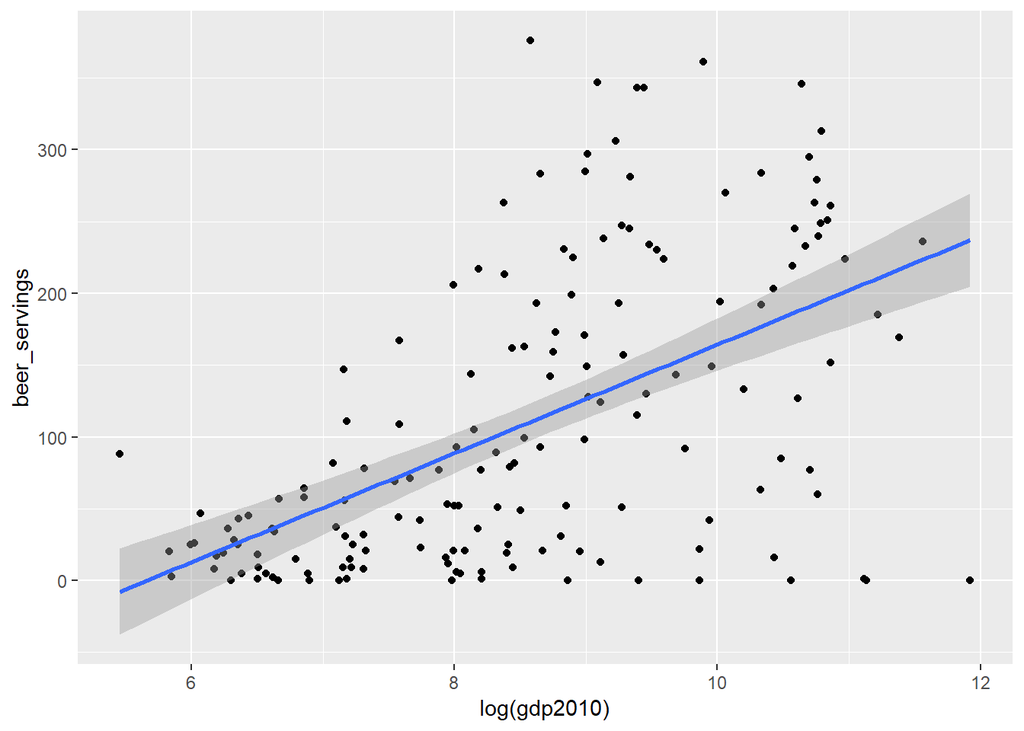

```r
ggplot(alchohol, aes(y = beer_servings, x = log(gdp2010))) +
  geom_point() +
  stat_smooth(method = "lm", se = TRUE, level = 0.95)
```

Note the following clarification: the prediction interval is a confidence interval to what would your prediction be when you recreate the experiment, and not the interval in which 95% of the points will fall into.